# League of Legends Summer Tournament Data Analysis

By William Weihnacht and Daniel Song

```python
import pandas as pd
import numpy as np
import matplotlib.pyplot as plt
import seaborn as sns
import statsmodels.formula.api
```

### Data collection

To collect the data for our project we were lucky in that there is a plethora of League related data widely accessible including [Riot’s](https://www.riotgames.com/en) own match data API. However, instead of scraping data from random public matches, we chose to collect data from an already existing professional League analysis website named [Oracle’s Elixir](http://oracleselixir.com/) so we can analyze the game at the highest level of play and in the current meta. This meant the main challenge here was reformatting it into a way that we wanted to use it.

```python
#read in dataset
data = pd.read_excel('./2019-summer-match-data-OraclesElixir-2019-06-24.xlsx')
```

To start off there is much more data than we need to get a good idea of the current meta game so we can go ahead and select the most relevant 45 of the 98 columns.

```python
#select relevent columns
less_data = data[['date','gameid','playerid','player','team','side','gamelength','result','k','d','a','teamkills','teamdeaths','fb','kpm','okpm','fd','fdtime','teamdragkills','oppdragkills','ft','firstmidouter','firsttothreetowers','teamtowerkills','opptowerkills','fbaron','teambaronkills','oppbaronkills','dmgtochampsperminute','wpm','wcpm','totalgold','goldspent','csat10','oppcsat10','csdat10','goldat10','oppgoldat10','gdat10','goldat15','oppgoldat15','gdat15','xpat10','oppxpat10','xpdat10']]
```

### Data Processing

Now that we have a DataFrame full of statistics we can start to break it down into more relevant subsets. We want to look at performance based on individual champions, as well as what the most successful teams are prioritizing doing.

To get clean data for team stats we will simply select all rows where the player is listed as team, which means the column contains the team averages for that game. Once we have aggregated these we group all rows that correspond to the same team together and average them to get a table of team averages across all games this tournament. Doing so makes the variables playerid, team kills, and team deaths, redundant or obsolete so they are dropped.

```python
#team stats for each game
team_stats = less_data.loc[less_data['player'] == 'Team']
```

```python
#team data averaged across all games
avg_team_data = team_stats.groupby(['team']).mean()
avg_team_data.drop(['playerid','teamkills','teamdeaths'],1,inplace=True)
avg_team_data.head()
```

| team | gamelength | result | k | d | a | kpm | okpm | fdtime | teamdragkills | oppdragkills | ... | csdat10 | goldat10 | oppgoldat10 | gdat10 | goldat15 | oppgoldat15 | gdat15 | xpat10 | oppxpat10 | xpdat10 |
| --- | --- | --- | --- | --- | --- | --- | --- | --- | --- | --- | --- | --- | --- | --- | --- | --- | --- | --- | --- | --- | --- |
| 100 Thieves | 34.847917 | 0.375000 | 9.625000 | 12.125000 | 26.000000 | 0.271693 | 0.356500 | 10.055717 | 1.250000 | 3.250000 | ... | -33.250000 | 14695.750000 | 16037.625000 | -1341.875000 | 23126.125000 | 25380.750000 | -2254.625000 | 18223.000000 | 18705.375000 | -482.375000 |
| AHQ e-Sports Club | 36.662500 | 0.625000 | 12.625000 | 9.125000 | 29.500000 | 0.366591 | 0.250843 | 8.835340 | 3.000000 | 2.250000 | ... | -0.625000 | 15873.500000 | 15221.000000 | 652.500000 | 25036.250000 | 23743.625000 | 1292.625000 | 18590.375000 | 18360.500000 | 229.875000 |
| Afreeca Freecs | 33.570833 | 0.500000 | 12.312500 | 12.312500 | 28.750000 | 0.373947 | 0.366536 | 9.033907 | 2.437500 | 2.375000 | ... | 14.937500 | 15656.125000 | 15645.375000 | 10.750000 | 24777.562500 | 24646.750000 | 130.812500 | 18476.437500 | 18545.875000 | -69.437500 |
| Alpha Esports | 29.338095 | 0.428571 | 9.000000 | 11.142857 | 23.142857 | 0.302010 | 0.386755 | 7.372802 | 1.571429 | 2.285714 | ... | -13.857143 | 15398.142857 | 15415.428571 | -17.285714 | 23850.142857 | 24148.714286 | -298.571429 | 18245.571429 | 19069.428571 | -823.857143 |
| Bilibili Gaming | 31.320833 | 0.500000 | 11.416667 | 13.000000 | 29.000000 | 0.365807 | 0.445617 | NaN | 1.416667 | 2.416667 | ... | NaN | NaN | NaN | NaN | NaN | NaN | NaN | NaN | NaN | NaN |

5 rows × 35 columns

Next, we look at individual player data with the goal of finding what champions are used to the greatest effect. Some data is listed as either and empty string or a single space instead of “not a number” so we change both to NaN then drop them all at once.

```python
#collect average champion data
champ_data = data[['champion','position','result','earnedgoldshare','dmgshare','wardshare']]
champ_data.replace('', np.nan, inplace=True)
champ_data.replace(' ', np.nan, inplace=True)
champ_data.dropna(inplace=True)
champ_data.head()
```

|  | champion | position | result | earnedgoldshare | dmgshare | wardshare |
| --- | --- | --- | --- | --- | --- | --- |
| 0 | Aatrox | Top | 1 | 0.235685 | 0.273088 | 0.201835 |
| 1 | Hecarim | Jungle | 1 | 0.176841 | 0.123226 | 0.100917 |
| 2 | Sylas | Middle | 1 | 0.254719 | 0.255993 | 0.091743 |
| 3 | Varus | ADC | 1 | 0.224666 | 0.253611 | 0.110092 |
| 4 | Galio | Support | 1 | 0.108088 | 0.094082 | 0.495413 |

### Data Visualization

First off, since I have seen theories that teams wearing a certain color might have a slight advantage in various sports and video games so I thought it would be interesting. I was impressed when I found that blue teams have one 55.6% of the time. After some research, I found that this is because the blue team gets to pick the first champion giving them a statistical edge in pro play.

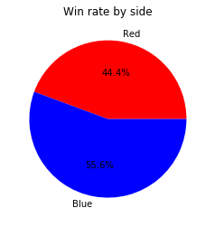

```python
#calculate side vs win%
r = 0
b = 0

for index,row in team_stats.iterrows():
    if row['side'] == 'Red' and row['result'] == 1:
        r += 1
    elif row['side'] == 'Blue' and row['result'] == 1:
        b += 1

plt.pie([r,b],labels=['Red','Blue'],colors=['Red','Blue'],autopct='%1.1f%%')
plt.title("Win rate by side")
plt.show()
```

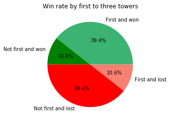

```python
#calculate first to 3 towers vs win%
f_w = 0
f_l = 0
nf_w = 0
nf_l = 0

for index,row in team_stats.iterrows():
    if row['firsttothreetowers'] == 1 and row['result'] == 1:
        f_w += 1
    elif row['firsttothreetowers'] == 1 and row['result'] == 0:
        f_l += 1
    elif row['firsttothreetowers'] == 0 and row['result'] == 1:
        nf_w += 1
    elif row['firsttothreetowers'] == 0 and row['result'] == 0:
        nf_l += 1

plt.pie([f_w,nf_w,nf_l,f_l],labels=['First and won','Not first and won','Not first and lost','First and lost'],colors=['MediumSeaGreen','Green','Red','Salmon'],autopct='%1.1f%%')
plt.title("Win rate by first to three towers")
plt.show()
```

Based on this it makes sense that the first tower will give you slightly less but still significantly increased odds of winning. It’s interesting that the first tower gives an 8.7% bump but getting the next two first will only increase your chance of winning another 5.7%. This is testament to the fact that resources can be used to “snowball” an advantage and their value diminishes as time goes on.

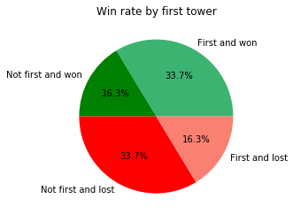

```python
#calculate first tower vs win%
ft_w = 0
ft_l = 0
nft_w = 0
nft_l = 0

for index,row in team_stats.iterrows():
    if row['ft'] == 1 and row['result'] == 1:
        ft_w += 1
    elif row['ft'] == 1 and row['result'] == 0:
        ft_l += 1
    elif row['ft'] == 0 and row['result'] == 1:
        nft_w += 1
    elif row['ft'] == 0 and row['result'] == 0:
        nft_l += 1

plt.pie([ft_w,nft_w,nft_l,ft_l],labels=['First and won','Not first and won','Not first and lost','First and lost'],colors=['MediumSeaGreen','Green','Red','Salmon'],autopct='%1.1f%%')
plt.title("Win rate by first tower")
plt.show()
```

Similarly, first blood only gives a 3.6% increased chance of winning which is reasonable because it only nets you 400 gold as opposed to 1000 for a tower or 300 for a normal kill.

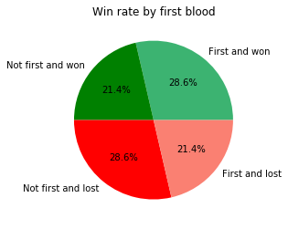

```python
#calculate first blood vs win%
fb_w = 0
fb_l = 0
nfb_w = 0
nfb_l = 0

for index,row in team_stats.iterrows():
    if row['fb'] == 1 and row['result'] == 1:
        fb_w += 1
    elif row['fb'] == 1 and row['result'] == 0:
        fb_l += 1
    elif row['fb'] == 0 and row['result'] == 1:
        nfb_w += 1
    elif row['fb'] == 0 and row['result'] == 0:
        nfb_l += 1

plt.pie([fb_w,nfb_w,nfb_l,fb_l],labels=['First and won','Not first and won','Not first and lost','First and lost'],colors=['MediumSeaGreen','Green','Red','Salmon'],autopct='%1.1f%%')
plt.title("Win rate by first blood")
plt.show()
```

Looking at first to kill a dragon, it is more significant than first blood but less than first tower. Dragons are important for building advantages as their buff lasts the entire game but don’t give the same gold and lane control advantage as a tower.

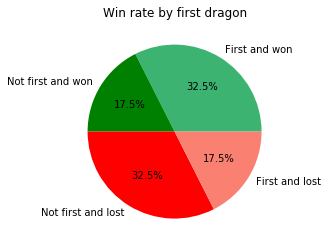

```python
#calculate first dragon vs win%
fd_w = 0
fd_l = 0
nfd_w = 0
nfd_l = 0

for index,row in team_stats.iterrows():
    if row['fd'] == 1 and row['result'] == 1:
        fd_w += 1
    elif row['fd'] == 1 and row['result'] == 0:
        fd_l += 1
    elif row['fd'] == 0 and row['result'] == 1:
        nfd_w += 1
    elif row['fd'] == 0 and row['result'] == 0:
        nfd_l += 1

plt.pie([fd_w,nfd_w,nfd_l,fd_l],labels=['First and won','Not first and won','Not first and lost','First and lost'],colors=['MediumSeaGreen','Green','Red','Salmon'],autopct='%1.1f%%')
plt.title("Win rate by first dragon")
plt.show()
```

Next, we will look at individual role/champion data. First, I count the amount of times each champion was played at a certain position and remove champions who were not used at least 10 times in a position. Since we are dealing with averages having outliers such as a champion who was used once at position and won would skew the data.

```python
#count each time a champion was picked for each position
pick_counts = champ_data.groupby(['position','champion']).size()
```

```python
#remove data for champions used less than 10 times at a given position
champ_data2 = []
for index,row in champ_data.iterrows():
    if pick_counts[row['position']][row['champion']] > 10:
        champ_data2.append(row)

champ_data2 = pd.DataFrame(champ_data2)
```

Here I group the data by position and champion and average it, rename result to win percent for clarity, and then split the DataFrame by position played, and made a little function to graph each position cleanly.

```python
#Average the data
avg_position_data = champ_data2.groupby(['position','champion']).mean()
avg_position_data.rename({'result':'Win Percent'},inplace=True,axis=1)
```

```python
#Split the data by position
top,mid,adc,jg,sup = [],[],[],[],[]
for index,row in avg_position_data.iterrows():
    if index[0] == "ADC":
        adc.append(row)
    if index[0] == "Jungle":
        jg.append(row)
    if index[0] == "Middle":
        mid.append(row)
    if index[0] == "Support":
        sup.append(row)
    if index[0] == "Top":
        top.append(row)
```

```python
#function to clean the data for graphing
def reindex(pos):
    df = pd.DataFrame(pos)
    i = []
    for index,row in df.iterrows():
        i.append(index[1])
    df.index = i
    return df
```

```python
#applying the function to the dataframes created
top = reindex(top)
mid = reindex(mid)
adc = reindex(adc)
jg = reindex(jg)
sup = reindex(sup)
```

In the top position the big winner jumps out a Sylas with a win percentage of over 60% over 24 games. Sylas was a strong Mid-lanner in patch 9.1 but it is a testament to his utility that he is used in top lane too. Interestingly the overall damage and gold share of the most successful heroes in this rank is lower than that of the more middle of the pack ones which makes sense in a way because top is an isolated position and one can have success in their own lane despite their team losing control in other lanes.

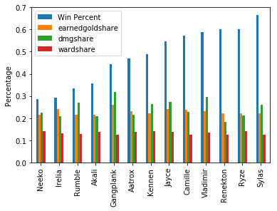

```python
#Champion stats for the position top
top.sort_values('Win Percent').plot.bar()
plt.ylabel("Percentage")
plt.show()
```

In the middle role, we see Sylas is also dominant here, but on par with Yasuo, another strong pick. There is a lot of variety in this position and some overlap with top as they have similar roles. Akali, for example is used in both but to more success in middle than top likely because she is more of a ganker (ganking refers to ambushing an enemy in a different lane). Once again some of the lower win-rate heroes have good damage and gold share but this can once again potentially be attributed to the bottom-lane failing to over-power the enemy and being pushed in, leading to higher proportional sucsess from the more individual middle and top lanes.

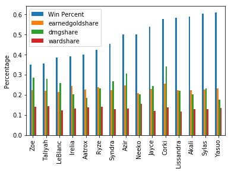

```python
#Champion stats for the position middle
mid.sort_values('Win Percent').plot.bar()
plt.ylabel("Percentage")
plt.show()
```

The ADC role appears to have more of a set meta with only 8 commonly used champions as opposed to the 15 used at middle. ADC, which stands for attack damage carry, is tasked with outputting the majority of team damage towards the end of the game. While Kalista has by far the highest win rate this can be a little deceiving as she was only used 11 times compared to the 92 of Sivir and 90 of Xayah. With a respectable win rate of 55% in 28 games Varus seems to be one of the stronger damage dealers at this position, while the supposedly meta aformentioned Xayah and Sivir saw mediocre win rates.

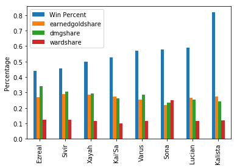

```python
#Champion stats for the position ADC
adc.sort_values('Win Percent').plot.bar()
plt.ylabel("Percentage")
plt.show()
```

Junglers are tasked with killing their jungles spawns, stealing the enemies, and ganking. Once again, Karthus has a deceptively high win rate given he has only played 11 games but nonetheless he is an effective damage dealer but lacks the utility of other champions. Trundle is also effective although he lacks damage he provides utility by hindering the enemies in gank situations to secure extra kills, accounting for his low damage share yet high success.

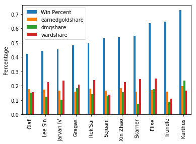

```python
#Champion stats for the position jungle
jg.sort_values('Win Percent').plot.bar()
plt.ylabel("Percentage")
plt.show()
```

The support position is tasked with vision control and enabling the ADC and other roles through buffs. Once again, the highest win percentage, Pyke, is from a smaller sample size. However, unlike some other roles two of the most played heroes are also among the most successful. Rakan is strong as a standard healer while Tahm Kench has an ultimate that provides motility to teammates and a stun.

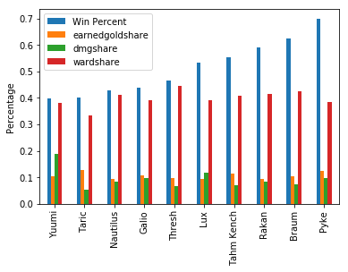

```python
#Champion stats for the position support
sup.sort_values('Win Percent').plot.bar()
plt.ylabel("Percentage")
plt.show()
```

This is a helper function that plots a variable against win rate for team averages and plots and returns the ordinary least squares.

```python
#make a list of each team
teams = avg_team_data.index.values.tolist()

#function to do a ols and graph win percentage vs a variable
def plot_team_data(x):
    plt.figure(figsize=(15,15))

    ols = statsmodels.formula.api.ols(formula="result ~ " + x, data=avg_team_data).fit()

    l=[]
    for index,row in avg_team_data.iterrows():
        plt.scatter(row[x],row['result'])
        l.append(row['result']*ols.params[1] + ols.params[0])

    plt.legend(teams)
    plt.plot(avg_team_data['result'],l)
    plt.ylabel("Win percentage")
    plt.xlabel(x)
    plt.show()

    return ols
```

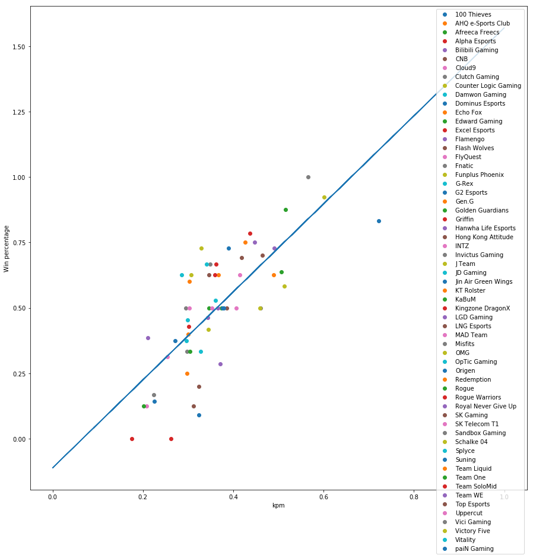

```
<statsmodels.regression.linear_model.RegressionResultsWrapper at 0x7fe1a292ac50>
```

```python
#win percent vs kills per minute
plot_team_data('kpm')
```

```python
from sklearn.model_selection import train_test_split
from scipy.stats import f
import seaborn as sns
from sklearn import model_selection
from sklearn import linear_model
from sklearn import preprocessing
from sklearn.preprocessing import LabelEncoder
import statsmodels.formula.api as smf
import warnings
```

```python
from sklearn.model_selection import KFold
warnings.filterwarnings('ignore')
from sklearn.model_selection import cross_val_score, cross_val_predict
from sklearn import metrics
from sklearn import datasets, linear_model
```

```python
by_team_data = data.loc[less_data['player'] == 'Team']
by_team_data.fillna(0, inplace = True)
team_data = by_team_data.groupby(['team']).mean()
result = team_data[['result']]
```

### Supervised Machine Learning

We did supervised machine learning on seven groups of factors to determine win percentage:

1. champion kills
   - kpm = kills per minute
   - teamkills = champion kills made by team
   - a = assists, assisted kills
2. not dying
   - teamdeaths = number of total deaths by team
3. large monster kills
   - teamdragkills = Total dragons killed by team.
   - herald = Rift herald taken (1 yes, 0 opponent took it, blank herald not killed).
   - fbaron = First baron of game killed (1 yes, 0 no).
   - teambaronkills = Total barons killed by team.
4. tower kills
   - ft = First tower of game killed (1 yes, 0 no).
   - firstmidouter = First team to kill mid lane outer tower (1 yes, 0 no).
   - firsttothreetowers = First team to kill three towers (1 yes, 0 no).
   - teamtowerkills = Total towers killed by team.
   - fttime = First tower kill time, in minutes.
5. creep score
   - minionkills = Lane minions killed.
   - monsterkills = Neutral monsters killed.
   - cspm = Creep score per minute. All creep score variables include minions and monsters.
   - csat10 = Creep score at 10:00.
   - csdat10 = Creep score difference at 10:00.
6. vision
   - wards = Total wards placed (of all types).
   - wpm = Wards placed per minute (or all types).
   - wardkills = Total wards cleared/killed (of all types).
   - wcpm = Total wards cleared/killed per minute (of all types).
   - visionwards = Vision/control wards placed.
   - visionwardbuys = Vision/control wards purchased.
7. economics
   - totalgold = Total gold earned from all sources.
   - earnedgpm = Earned gold per minute.
   - goldspent = Total gold spent.
   - gspd = Gold spent percentage difference.
   - goldat10 = Total gold earned at 10:00.
   - gdat10 = Gold difference at 10:00.
   - goldat15 = Total gold earned at 15:00.
   - gdat15 = Gold difference at 15:00.

### 1. Win Percentage based on Champion Kills Per Minute

```python
champ_kills = team_data[['kpm','teamkills','a']]
# champ_kills = team_data[['kpm']]
X = champ_kills
y = result
# Split data into Train and Test
X_train, X_test, y_train, y_test = model_selection.train_test_split(X, y)
lm = linear_model.LinearRegression()
model = lm.fit(X_train, y_train)
```

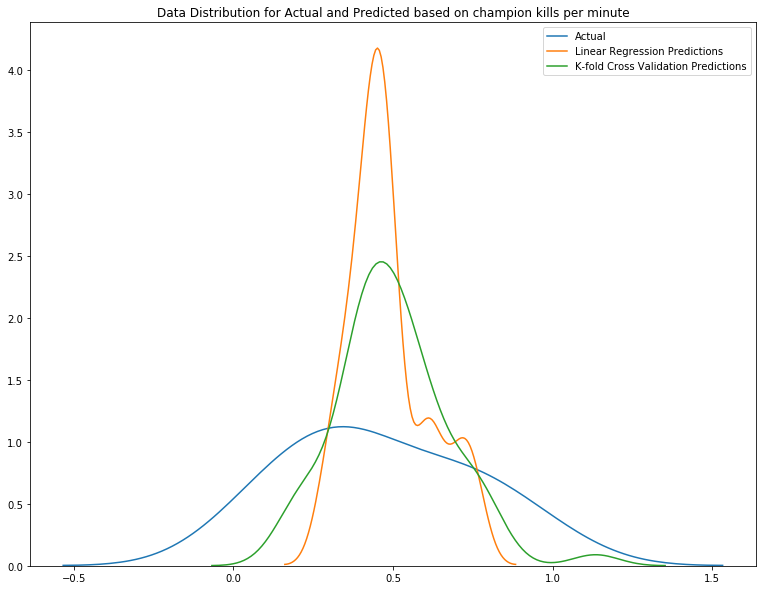

```python
# Fit the Linear Regression on Train split
champ_kills_LRM = smf.OLS(y_train, X_train).fit()

# Predict using Test split
preds_lr = champ_kills_LRM.predict(X_test)
KFCV_predictions = cross_val_predict(model, X, y, cv=5)

# Plot how the predicted win_ratio compares to actual win ratio
f, ax = plt.subplots(figsize=(13,10))
plt.title('Data Distribution for Actual and Predicted based on champion kills per minute')
sns.distplot(y_test, hist=False, label="Actual", ax=ax)
sns.distplot(preds_lr, hist=False, label="Linear Regression Predictions", ax=ax)
sns.distplot(KFCV_predictions, hist=False, label="K-fold Cross Validation Predictions", ax=ax)
plt.show()
```

```python
champ_kills_LRM.summary()
```

OLS Regression Results

| Dep. Variable: | result | R-squared: | 0.910 |
| --- | --- | --- | --- |
| Model: | OLS | Adj. R-squared: | 0.904 |
| Method: | Least Squares | F-statistic: | 142.0 |
| Date: | Fri, 19 Jul 2019 | Prob (F-statistic): | 5.18e-22 |
| Time: | 15:46:56 | Log-Likelihood: | 18.895 |
| No. Observations: | 45 | AIC: | -31.79 |
| Df Residuals: | 42 | BIC: | -26.37 |
| Df Model: | 3 |  |  |
| Covariance Type: | nonrobust |  |  |

|  | coef | std err | t | P>\|t\| | [0.025 | 0.975] |
| --- | --- | --- | --- | --- | --- | --- |
| kpm | 1.5135 | 0.771 | 1.963 | 0.056 | -0.042 | 3.069 |
| teamkills | -0.0174 | 0.046 | -0.379 | 0.706 | -0.110 | 0.075 |
| a | 0.0055 | 0.015 | 0.378 | 0.707 | -0.024 | 0.035 |

| Omnibus: | 1.394 | Durbin-Watson: | 2.166 |
| --- | --- | --- | --- |
| Prob(Omnibus): | 0.498 | Jarque-Bera (JB): | 1.274 |
| Skew: | -0.268 | Prob(JB): | 0.529 |
| Kurtosis: | 2.373 | Cond. No. | 958. |

Warnings:  
[1] Standard Errors assume that the covariance matrix of the errors is correctly specified.

### 2. Win Percentage based on Not Dying

```python
not_dying = team_data[['teamdeaths']]
X = not_dying
# Split data into Train and Test
X_train, X_test, y_train, y_test = model_selection.train_test_split(X, y)
lm = linear_model.LinearRegression()
model = lm.fit(X_train, y_train)
```

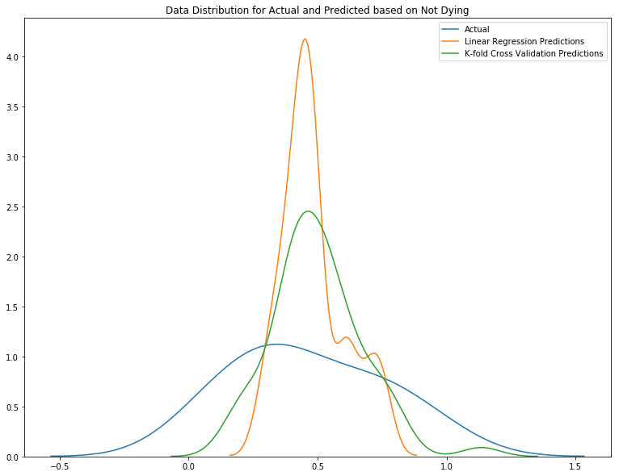

```python
# Fit the Linear Regression on Train split
notDying_LRM = smf.OLS(y_train, X_train).fit()

# Predict using Test split
preds_lr = notDying_LRM.predict(X_test)
KFCV_predictions = cross_val_predict(model, X, y, cv=5)

# Plot how the predicted win_ratio compares to actual win ratio
f, ax = plt.subplots(figsize=(13,10))
plt.title('Data Distribution for Actual and Predicted based on Not Dying')
sns.distplot(y_test, hist=False, label="Actual", ax=ax)
sns.distplot(preds_lr, hist=False, label="Linear Regression Predictions", ax=ax)
sns.distplot(KFCV_predictions, hist=False, label="K-fold Cross Validation Predictions", ax=ax)
plt.show()
```

```python
notDying_LRM.summary()
```

OLS Regression Results

| Dep. Variable: | result | R-squared: | 0.705 |
| --- | --- | --- | --- |
| Model: | OLS | Adj. R-squared: | 0.698 |
| Method: | Least Squares | F-statistic: | 104.9 |
| Date: | Fri, 19 Jul 2019 | Prob (F-statistic): | 3.17e-13 |
| Time: | 15:46:56 | Log-Likelihood: | -9.5068 |
| No. Observations: | 45 | AIC: | 21.01 |
| Df Residuals: | 44 | BIC: | 22.82 |
| Df Model: | 1 |  |  |
| Covariance Type: | nonrobust |  |  |

|  | coef | std err | t | P>\|t\| | [0.025 | 0.975] |
| --- | --- | --- | --- | --- | --- | --- |
| teamdeaths | 0.0375 | 0.004 | 10.243 | 0.000 | 0.030 | 0.045 |

| Omnibus: | 1.489 | Durbin-Watson: | 1.550 |
| --- | --- | --- | --- |
| Prob(Omnibus): | 0.475 | Jarque-Bera (JB): | 1.091 |
| Skew: | 0.086 | Prob(JB): | 0.580 |
| Kurtosis: | 2.257 | Cond. No. | 1.00 |

Warnings:  
[1] Standard Errors assume that the covariance matrix of the errors is correctly specified.

### The R-squared value shows that only about 70% of the variance is explained by the factor of not dying.

### teamdeaths came out as statistically relevant because of its low p-value.

### 3. Win Percentage based on Large Monster Kills

```python
largeMonsterKills = team_data[['teamdragkills','herald','heraldtime','fbaron','fbarontime','teambaronkills']]
# monster_kills = team_data[['teamdragkills']]
X = largeMonsterKills
# Split data into Train and Test
X_train, X_test, y_train, y_test = model_selection.train_test_split(X, y)
lm = linear_model.LinearRegression()
model = lm.fit(X_train, y_train)
```

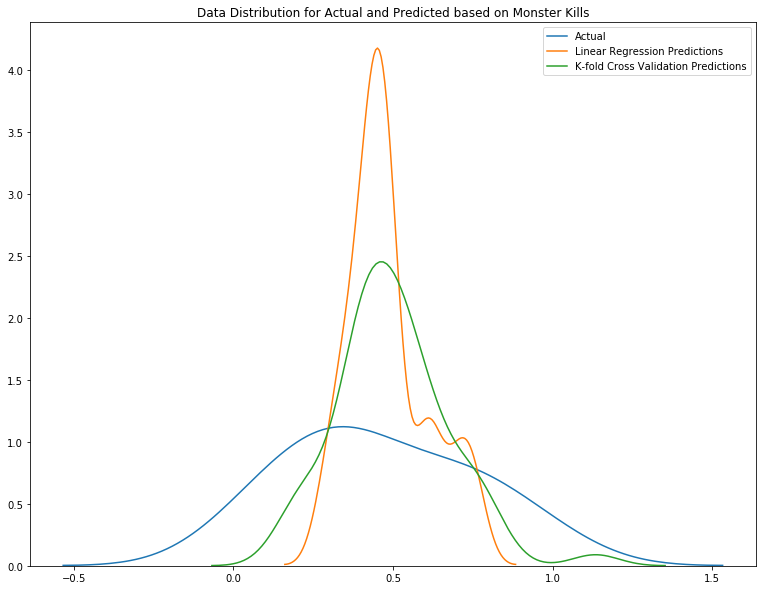

```python
# Fit the Linear Regression on Train split
largeMonsterKillsLRM = smf.OLS(y_train, X_train).fit()

# Predict using Test split
preds_lr = largeMonsterKillsLRM.predict(X_test)
KFCV_predictions = cross_val_predict(model, X, y, cv=5)

# Plot how the predicted win_ratio compares to actual win ratio
f, ax = plt.subplots(figsize=(13,10))
plt.title('Data Distribution for Actual and Predicted based on Monster Kills')
sns.distplot(y_test, hist=False, label="Actual", ax=ax)
sns.distplot(preds_lr, hist=False, label="Linear Regression Predictions", ax=ax)
sns.distplot(KFCV_predictions, hist=False, label="K-fold Cross Validation Predictions", ax=ax)
plt.show()
```

```python
largeMonsterKillsLRM.summary()
```

OLS Regression Results

| Dep. Variable: | result | R-squared: | 0.920 |
| --- | --- | --- | --- |
| Model: | OLS | Adj. R-squared: | 0.908 |
| Method: | Least Squares | F-statistic: | 75.05 |
| Date: | Fri, 19 Jul 2019 | Prob (F-statistic): | 7.15e-20 |
| Time: | 15:48:52 | Log-Likelihood: | 18.636 |
| No. Observations: | 45 | AIC: | -25.27 |
| Df Residuals: | 39 | BIC: | -14.43 |
| Df Model: | 6 |  |  |
| Covariance Type: | nonrobust |  |  |

|  | coef | std err | t | P>\|t\| | [0.025 | 0.975] |
| --- | --- | --- | --- | --- | --- | --- |
| teamdragkills | 0.2203 | 0.021 | 10.262 | 0.000 | 0.177 | 0.264 |
| herald | -0.0298 | 0.162 | -0.183 | 0.856 | -0.358 | 0.299 |
| heraldtime | 0.0327 | 0.017 | 1.915 | 0.063 | -0.002 | 0.067 |
| fbaron | 0.2969 | 0.291 | 1.020 | 0.314 | -0.292 | 0.885 |
| fbarontime | -0.0212 | 0.008 | -2.557 | 0.015 | -0.038 | -0.004 |
| teambaronkills | 0.0395 | 0.206 | 0.192 | 0.849 | -0.377 | 0.456 |

| Omnibus: | 1.355 | Durbin-Watson: | 2.342 |
| --- | --- | --- | --- |
| Prob(Omnibus): | 0.508 | Jarque-Bera (JB): | 0.984 |
| Skew: | 0.362 | Prob(JB): | 0.612 |
| Kurtosis: | 2.976 | Cond. No. | 323. |

Warnings:  
[1] Standard Errors assume that the covariance matrix of the errors is correctly specified.

### 4. Win Percentage based on Tower Kills

```python
tower_kills = team_data[['ft','firstmidouter','firsttothreetowers','teamtowerkills','fttime']]
X = tower_kills
# Split data into Train and Test
X_train, X_test, y_train, y_test = model_selection.train_test_split(X, y)
lm = linear_model.LinearRegression()
model = lm.fit(X_train, y_train)
```

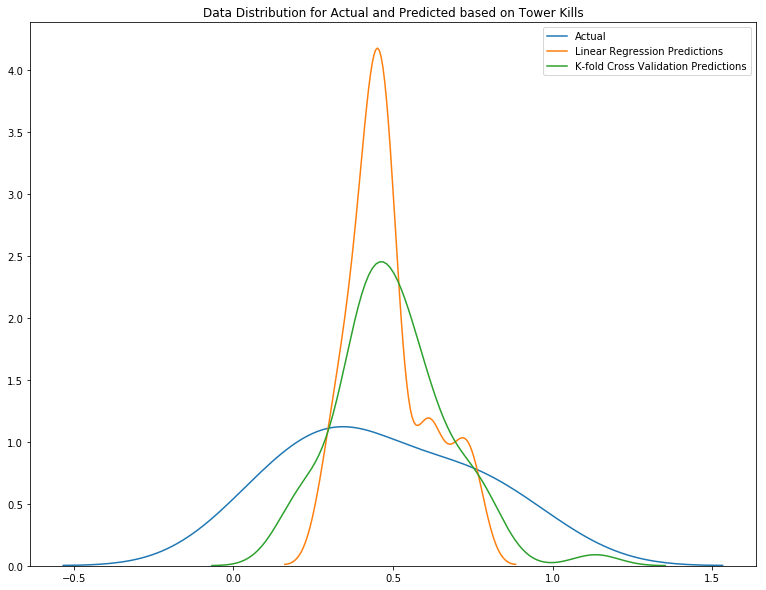

```python
# Fit the Linear Regression on Train split
towerKillsLRM = smf.OLS(y_train, X_train).fit()

# Predict using Test split
preds_lr = towerKillsLRM.predict(X_test)
KFCV_predictions = cross_val_predict(model, X, y, cv=5)

# Plot how the predicted win_ratio compares to actual win ratio
f, ax = plt.subplots(figsize=(13,10))
plt.title('Data Distribution for Actual and Predicted based on Tower Kills')
sns.distplot(y_test, hist=False, label="Actual", ax=ax)
sns.distplot(preds_lr, hist=False, label="Linear Regression Predictions", ax=ax)
sns.distplot(KFCV_predictions, hist=False, label="K-fold Cross Validation Predictions", ax=ax)
plt.show()
```

```python
towerKillsLRM.summary()
```

OLS Regression Results

| Dep. Variable: | result | R-squared: | 0.982 |
| --- | --- | --- | --- |
| Model: | OLS | Adj. R-squared: | 0.980 |
| Method: | Least Squares | F-statistic: | 432.2 |
| Date: | Fri, 19 Jul 2019 | Prob (F-statistic): | 1.11e-33 |
| Time: | 15:48:53 | Log-Likelihood: | 52.331 |
| No. Observations: | 45 | AIC: | -94.66 |
| Df Residuals: | 40 | BIC: | -85.63 |
| Df Model: | 5 |  |  |
| Covariance Type: | nonrobust |  |  |

|  | coef | std err | t | P>\|t\| | [0.025 | 0.975] |
| --- | --- | --- | --- | --- | --- | --- |
| ft | -0.1111 | 0.097 | -1.146 | 0.258 | -0.307 | 0.085 |
| firstmidouter | -0.1547 | 0.136 | -1.134 | 0.264 | -0.430 | 0.121 |
| firsttothreetowers | 0.3759 | 0.141 | 2.669 | 0.011 | 0.091 | 0.660 |
| teamtowerkills | 0.0972 | 0.004 | 25.619 | 0.000 | 0.090 | 0.105 |
| fttime | -0.0097 | 0.003 | -3.270 | 0.002 | -0.016 | -0.004 |

| Omnibus: | 0.349 | Durbin-Watson: | 1.950 |
| --- | --- | --- | --- |
| Prob(Omnibus): | 0.840 | Jarque-Bera (JB): | 0.365 |
| Skew: | 0.192 | Prob(JB): | 0.833 |
| Kurtosis: | 2.782 | Cond. No. | 210. |

Warnings:  
[1] Standard Errors assume that the covariance matrix of the errors is correctly specified.

### 5. Win Percentage based on Creep Score

```python
minion_kills = team_data[['minionkills','monsterkills','cspm','csat10','csdat10']]
X = minion_kills
# Split data into Train and Test
X_train, X_test, y_train, y_test = model_selection.train_test_split(X, y)
lm = linear_model.LinearRegression()
model = lm.fit(X_train, y_train)
```

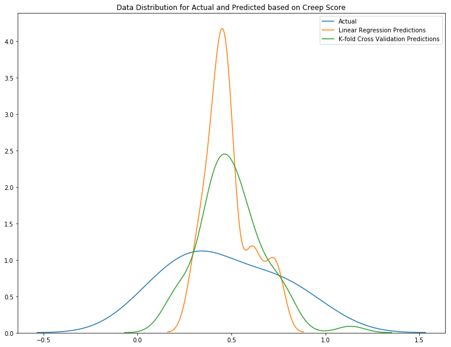

```python
# Fit the Linear Regression on Train split
minionKillsLRM = smf.OLS(y_train, X_train).fit()

# Predict using Test split
preds_lr = minionKillsLRM.predict(X_test)
KFCV_predictions = cross_val_predict(model, X, y, cv=5)

# Plot how the predicted win_ratio compares to actual win ratio
f, ax = plt.subplots(figsize=(13,10))
plt.title('Data Distribution for Actual and Predicted based on Creep Score')
sns.distplot(y_test, hist=False, label="Actual", ax=ax)
sns.distplot(preds_lr, hist=False, label="Linear Regression Predictions", ax=ax)
sns.distplot(KFCV_predictions, hist=False, label="K-fold Cross Validation Predictions", ax=ax)
plt.show()
```

```python
minionKillsLRM.summary()
```

OLS Regression Results

| Dep. Variable: | result | R-squared: | 0.609 |
| --- | --- | --- | --- |
| Model: | OLS | Adj. R-squared: | 0.560 |
| Method: | Least Squares | F-statistic: | 12.47 |
| Date: | Fri, 19 Jul 2019 | Prob (F-statistic): | 2.52e-07 |
| Time: | 15:48:54 | Log-Likelihood: | -16.434 |
| No. Observations: | 45 | AIC: | 42.87 |
| Df Residuals: | 40 | BIC: | 51.90 |
| Df Model: | 5 |  |  |
| Covariance Type: | nonrobust |  |  |

|  | coef | std err | t | P>\|t\| | [0.025 | 0.975] |
| --- | --- | --- | --- | --- | --- | --- |
| minionkills | -0.0013 | 0.002 | -0.831 | 0.411 | -0.004 | 0.002 |
| monsterkills | 0.0075 | 0.005 | 1.432 | 0.160 | -0.003 | 0.018 |
| cspm | 0.0782 | 0.084 | 0.928 | 0.359 | -0.092 | 0.249 |
| csat10 | -0.0075 | 0.009 | -0.842 | 0.405 | -0.025 | 0.010 |
| csdat10 | 0.0007 | 0.006 | 0.114 | 0.910 | -0.011 | 0.013 |

| Omnibus: | 4.103 | Durbin-Watson: | 1.194 |
| --- | --- | --- | --- |
| Prob(Omnibus): | 0.129 | Jarque-Bera (JB): | 3.908 |
| Skew: | 0.679 | Prob(JB): | 0.142 |
| Kurtosis: | 2.510 | Cond. No. | 1.21e+03 |

Warnings:  
[1] Standard Errors assume that the covariance matrix of the errors is correctly specified.  
[2] The condition number is large, 1.21e+03. This might indicate that there are  
strong multicollinearity or other numerical problems.

### 6. Win Percentage based on Vision

```python
vision = team_data[['wards','wpm','wardkills','wcpm','visionwards','visionwardbuys']]
X = vision
# Split data into Train and Test
X_train, X_test, y_train, y_test = model_selection.train_test_split(X, y)
lm = linear_model.LinearRegression()
model = lm.fit(X_train, y_train)
```

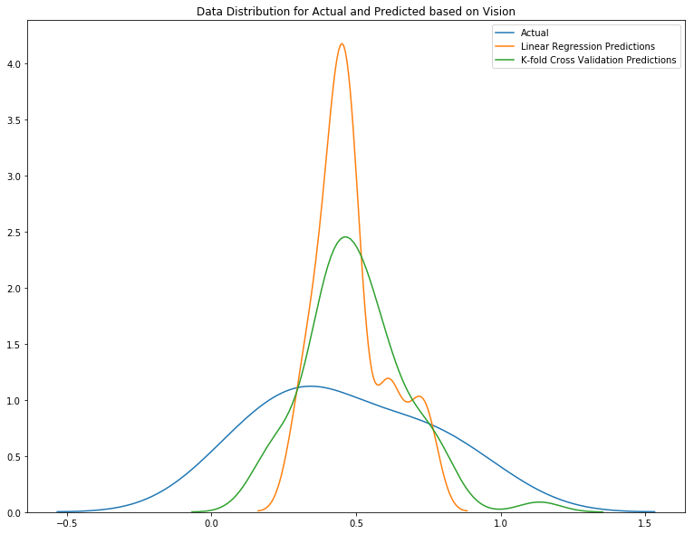

```python
# Fit the Linear Regression on Train split
visionLRM = smf.OLS(y_train, X_train).fit()

# Predict using Test split
preds_lr = visionLRM.predict(X_test)
KFCV_predictions = cross_val_predict(model, X, y, cv=5)

# Plot how the predicted win_ratio compares to actual win ratio
f, ax = plt.subplots(figsize=(13,10))
plt.title('Data Distribution for Actual and Predicted based on Vision')
sns.distplot(y_test, hist=False, label="Actual", ax=ax)
sns.distplot(preds_lr, hist=False, label="Linear Regression Predictions", ax=ax)
sns.distplot(KFCV_predictions, hist=False, label="K-fold Cross Validation Predictions", ax=ax)
plt.show()
```

```python
visionLRM.summary()
```

OLS Regression Results

| Dep. Variable: | result | R-squared: | 0.658 |
| --- | --- | --- | --- |
| Model: | OLS | Adj. R-squared: | 0.606 |
| Method: | Least Squares | F-statistic: | 12.52 |
| Date: | Fri, 19 Jul 2019 | Prob (F-statistic): | 8.12e-08 |
| Time: | 15:48:55 | Log-Likelihood: | -11.991 |
| No. Observations: | 45 | AIC: | 35.98 |
| Df Residuals: | 39 | BIC: | 46.82 |
| Df Model: | 6 |  |  |
| Covariance Type: | nonrobust |  |  |

|  | coef | std err | t | P>\|t\| | [0.025 | 0.975] |
| --- | --- | --- | --- | --- | --- | --- |
| wards | -0.0076 | 0.032 | -0.240 | 0.811 | -0.072 | 0.057 |
| wpm | 0.2048 | 1.142 | 0.179 | 0.859 | -2.106 | 2.515 |
| wardkills | -0.0249 | 0.071 | -0.348 | 0.729 | -0.169 | 0.119 |
| wcpm | 1.3001 | 2.571 | 0.506 | 0.616 | -3.900 | 6.500 |
| visionwards | 0.1176 | 0.069 | 1.692 | 0.099 | -0.023 | 0.258 |
| visionwardbuys | -0.1092 | 0.061 | -1.776 | 0.083 | -0.234 | 0.015 |

| Omnibus: | 4.657 | Durbin-Watson: | 1.547 |
| --- | --- | --- | --- |
| Prob(Omnibus): | 0.097 | Jarque-Bera (JB): | 4.394 |
| Skew: | 0.711 | Prob(JB): | 0.111 |
| Kurtosis: | 2.433 | Cond. No. | 7.01e+03 |

Warnings:  
[1] Standard Errors assume that the covariance matrix of the errors is correctly specified.  
[2] The condition number is large, 7.01e+03. This might indicate that there are  
strong multicollinearity or other numerical problems.

### 7. Win Percentage based on Economics

```python
economics = team_data[['totalgold','earnedgpm','goldspent','gspd','goldat10','gdat10','goldat15','gdat15']]
X = economics
# Split data into Train and Test
X_train, X_test, y_train, y_test = model_selection.train_test_split(X, y)
lm = linear_model.LinearRegression()
model = lm.fit(X_train, y_train)
```

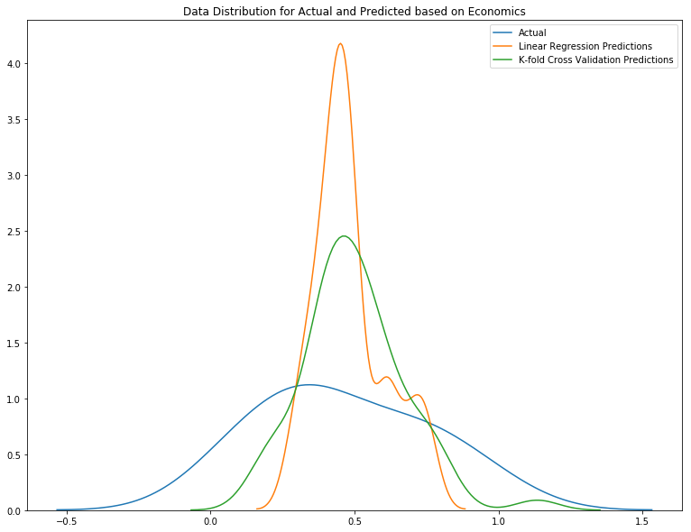

```python
# Fit the Linear Regression on Train split
econLRM = smf.OLS(y_train, X_train).fit()

# Predict using Test split
preds_lr = econLRM.predict(X_test)
KFCV_predictions = cross_val_predict(model, X, y, cv=5)

# Plot how the predicted win_ratio compares to actual win ratio
f, ax = plt.subplots(figsize=(13,10))
plt.title('Data Distribution for Actual and Predicted based on Economics')
sns.distplot(y_test, hist=False, label="Actual", ax=ax)
sns.distplot(preds_lr, hist=False, label="Linear Regression Predictions", ax=ax)
sns.distplot(KFCV_predictions, hist=False, label="K-fold Cross Validation Predictions", ax=ax)
plt.show()
```

```python
econLRM.summary()
```

OLS Regression Results

| Dep. Variable: | result | R-squared: | 0.925 |
| --- | --- | --- | --- |
| Model: | OLS | Adj. R-squared: | 0.909 |
| Method: | Least Squares | F-statistic: | 57.08 |
| Date: | Fri, 19 Jul 2019 | Prob (F-statistic): | 1.75e-18 |
| Time: | 15:48:55 | Log-Likelihood: | 21.156 |
| No. Observations: | 45 | AIC: | -26.31 |
| Df Residuals: | 37 | BIC: | -11.86 |
| Df Model: | 8 |  |  |
| Covariance Type: | nonrobust |  |  |

|  | coef | std err | t | P>\|t\| | [0.025 | 0.975] |
| --- | --- | --- | --- | --- | --- | --- |
| totalgold | 8.8e-06 | 8.44e-07 | 10.421 | 0.000 | 7.09e-06 | 1.05e-05 |
| earnedgpm | 0.0018 | 0.001 | 2.218 | 0.033 | 0.000 | 0.004 |
| goldspent | -1.076e-05 | 8.96e-06 | -1.200 | 0.238 | -2.89e-05 | 7.4e-06 |
| gspd | 0.6595 | 1.460 | 0.452 | 0.654 | -2.299 | 3.618 |
| goldat10 | -5.864e-08 | 0.000 | -0.000 | 1.000 | -0.000 | 0.000 |
| gdat10 | -3.083e-05 | 0.000 | -0.224 | 0.824 | -0.000 | 0.000 |
| goldat15 | -6.181e-05 | 0.000 | -0.550 | 0.586 | -0.000 | 0.000 |
| gdat15 | 3.229e-05 | 6.92e-05 | 0.466 | 0.644 | -0.000 | 0.000 |

| Omnibus: | 7.276 | Durbin-Watson: | 1.974 |
| --- | --- | --- | --- |
| Prob(Omnibus): | 0.026 | Jarque-Bera (JB): | 7.303 |
| Skew: | -0.579 | Prob(JB): | 0.0260 |
| Kurtosis: | 4.597 | Cond. No. | 4.51e+06 |

Warnings:  
[1] Standard Errors assume that the covariance matrix of the errors is correctly specified.  
[2] The condition number is large, 4.51e+06. This might indicate that there are  
strong multicollinearity or other numerical problems.

### Win Percentaged based on Most Relevant Factors

Most relevant categories:

```
- champion kills
- large monster kills
- tower kills
- economics
```

Most relevant factors:

[output not shown]

```python
relevant = team_data[['kpm', 'teamdeaths', 'teamdragkills', 'teamtowerkills', 'fttime', 'minionkills', 'monsterkills', 'visionwards', 'visionwardbuys', 'totalgold', 'earnedgpm', 'goldspent']]
X = relevant
# Split data into Train and Test
X_train, X_test, y_train, y_test = model_selection.train_test_split(X, y)
lm = linear_model.LinearRegression()
model = lm.fit(X_train, y_train)
```

[figure not shown]

```python
# Fit the Linear Regression on Train split
relevantLRM = smf.OLS(y_train, X_train).fit()

# Predict using Test split
preds_lr = relevantLRM.predict(X_test)
KFCV_predictions = cross_val_predict(model, X, y, cv=5)

# Plot how the predicted win_ratio compares to actual win ratio
f, ax = plt.subplots(figsize=(13,10))
plt.title('Data Distribution for Actual and Predicted based on Most Relevant Factors')
sns.distplot(y_test, hist=False, label="Actual", ax=ax)
sns.distplot(preds_lr, hist=False, label="Linear Regression Predictions", ax=ax)
sns.distplot(KFCV_predictions, hist=False, label="K-fold Cross Validation Predictions", ax=ax)
plt.show()
```

```python
relevantLRM.summary()
```

OLS Regression Results

| Dep. Variable: | result | R-squared: | 0.993 |
| --- | --- | --- | --- |
| Model: | OLS | Adj. R-squared: | 0.990 |
| Method: | Least Squares | F-statistic: | 369.2 |
| Date: | Fri, 19 Jul 2019 | Prob (F-statistic): | 1.54e-31 |
| Time: | 15:48:57 | Log-Likelihood: | 72.723 |
| No. Observations: | 45 | AIC: | -121.4 |
| Df Residuals: | 33 | BIC: | -99.77 |
| Df Model: | 12 |  |  |
| Covariance Type: | nonrobust |  |  |

|  | coef | std err | t | P>\|t\| | [0.025 | 0.975] |
| --- | --- | --- | --- | --- | --- | --- |
| kpm | 0.3788 | 0.165 | 2.289 | 0.029 | 0.042 | 0.716 |
| teamdeaths | -0.0230 | 0.005 | -4.484 | 0.000 | -0.033 | -0.013 |
| teamdragkills | -0.0371 | 0.021 | -1.768 | 0.086 | -0.080 | 0.006 |
| teamtowerkills | 0.0907 | 0.014 | 6.318 | 0.000 | 0.061 | 0.120 |
| fttime | 0.0175 | 0.011 | 1.584 | 0.123 | -0.005 | 0.040 |
| minionkills | -0.0004 | 0.000 | -0.937 | 0.356 | -0.001 | 0.000 |
| monsterkills | 0.0003 | 0.001 | 0.305 | 0.762 | -0.002 | 0.003 |
| visionwards | 0.0052 | 0.012 | 0.448 | 0.657 | -0.019 | 0.029 |
| visionwardbuys | -0.0002 | 0.011 | -0.020 | 0.984 | -0.023 | 0.023 |
| totalgold | 3.212e-06 | 2.41e-06 | 1.332 | 0.192 | -1.7e-06 | 8.12e-06 |
| earnedgpm | 0.0002 | 0.000 | 1.245 | 0.222 | -0.000 | 0.001 |
| goldspent | -7.457e-06 | 7.91e-06 | -0.943 | 0.353 | -2.35e-05 | 8.64e-06 |

| Omnibus: | 7.894 | Durbin-Watson: | 1.881 |
| --- | --- | --- | --- |
| Prob(Omnibus): | 0.019 | Jarque-Bera (JB): | 7.428 |
| Skew: | -0.697 | Prob(JB): | 0.0244 |
| Kurtosis: | 4.421 | Cond. No. | 1.48e+06 |

Warnings:  
[1] Standard Errors assume that the covariance matrix of the errors is correctly specified.  
[2] The condition number is large, 1.48e+06. This might indicate that there are  
strong multicollinearity or other numerical problems.

# Conclusion & Analysis

### The model based on the most relevant factors shown so far explains 99% of the variance in the data.

### Based on this model, the factors most relevant based on p-values turned out to be kpm, teamdeaths, teamtowerkills.

### So killing champions and towers as quickly as possible while not dying as much as possible.

A follow-up analysis would be to account for time relevant factors such as accomplishing certain objectives within a certain time frame (10, 15 minutes). Another route of follow-up analysis would be to include factors regarding champion selection and/or item selection. Since each champion and item is so unique in its own right and also because the data didn't include these factors, we reserved this analysis for possible follow-up.